# (PART) Financial Engineering

# Financial Transctions

## 거래(계약)라는 것은 무엇일까?

가장 이해하기 쉬운 형태는 **사다**와 **팔다**일 것입니다. 하지만 사다와 팔다를 다른 관점으로 바라보면, **주다(pay)**와 **받다(receive)**로 해석할 수 있습니다.

```
여기서 apple은 먹는 사과를 생각해도 되고, 애플 주식으로 생각해도 됩니다.

1. 1000원을 주고 apple을 사다.

2. 1000원을 받고 apple을 팔다.

3. 1000을 pay하고 apple을 receive하다

4. 1000을 receive하고 apple을 pay하다
```

## 4가지의 서로 다른 거래

pay와 receive를 시간과 함께 그려보겠습니다. $y$ 축 방향으로의 굵은 선은 apple, 보통 굵기의 선은 돈이고, 플러스 방향을 receive, 마이너스 방향을 pay로 생각하겠습니다. $x$축은 시간을 표시 합니다. $t=0$과 $t=T$이 있습니다. $T$는 우리가 지정한 특정 시점을 의미합니다. 1년 후로 생각해도 되고, 1개월 후로 생각해도 됩니다. $0$은 현재 시점입니다.

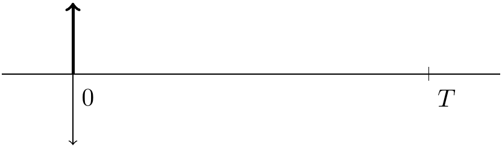

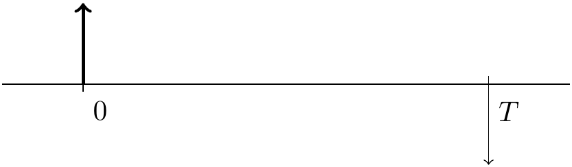

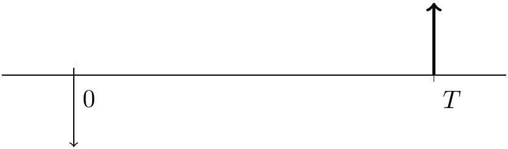

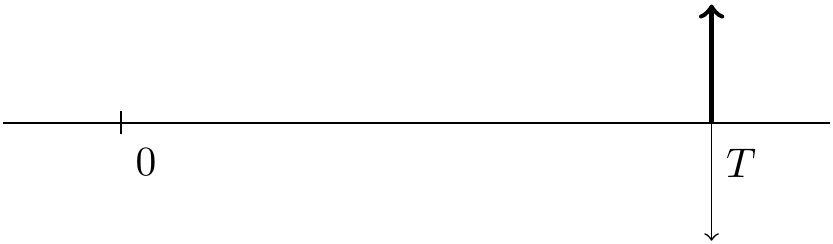

하나씩 살펴보겠습니다.

a는 우리가 일상적으로 생각하는 거래입니다. 1000을 pay하고, apple을 receive합니다.

b는현재 시점 $t=0$에 apple을 recieve하고, 미래의 특정 시점 $t=T$에 일정금액을 pay합니다. 이러한 거래는 신용을 기반으로 하는 거래로, 은행의 대출, 또는 채권(bond)이라는 금융상품과 관련이 있습니다.

```
b와 같은 형태의 거래를 예를 들어 보면,

1. 은행에서 1개월 만기 대출을 받아 apple을 사고, 1개월 후에 원금과 이자를 갚는다.

2. 1개월 만기 채권을 발행하여, 채권가격 1000으로 현재시점에서 apple을 사고, 1개월 후 채권의 소유자에게 채권의 원금이 1000과 정하여진 coupon (채권 발행시 미리 정한 이자를 의미함)을 지불한다.

3. 신용카드를 이용하여 apple을 사고, 1개월 후 신용카드 대금을 갚는다.
```

```
c는 주식이라는 금융상품의 초기 형태로 이해할 수 있습니다.
```